# Concessão de Crédito

Aprendizado de Máquina - Modelo de Classificação

# 1 Objetivos

- Construir Modelos Preditivos.
- Métricas de Performance
  - Sensitivity
  - Specificity
  - Precision
  - Recall
  - F1

# 2 Conjunto de dados

```r
df <- fread('../outputs/df_abt.csv',
                     sep=",",
                     showProgress = FALSE)[,-1] %>%
                     data.frame(stringsAsFactors = T)
```

```r
head(df)
```

|  | Loan_ID | Gender | Married | Dependents | Education | Self_Employed | ApplicantIncome | CoapplicantIncome | LoanAmount | Loan_Amount_Term | Credit_History | Property_Area | Loan_Status |
| --- | --- | --- | --- | --- | --- | --- | --- | --- | --- | --- | --- | --- | --- |
| 1 | LP001002 | Male | No | 0 | Graduate | No | 5849 | 0 | 153.6016 | 360 | 1 | Urban | Y |
| 2 | LP001003 | Male | Yes | 1 | Graduate | No | 4583 | 1508 | 128.0000 | 360 | 1 | Rural | N |
| 3 | LP001005 | Male | Yes | 0 | Graduate | Yes | 3000 | 0 | 66.0000 | 360 | 1 | Urban | Y |
| 4 | LP001006 | Male | Yes | 0 | Not Graduate | No | 2583 | 2358 | 120.0000 | 360 | 1 | Urban | Y |
| 5 | LP001008 | Male | No | 0 | Graduate | No | 6000 | 0 | 141.0000 | 360 | 1 | Urban | Y |
| 6 | LP001011 | Male | Yes | 2 | Graduate | Yes | 5417 | 4196 | 267.0000 | 360 | 1 | Urban | Y |

## 2.1 Levels Vars

```r
lapply(df[,lapply(df,class)=='factor'][,-1],levels)
```

```
## $Gender
## [1] "Female" "Male"   "vnd"
##
## $Married
## [1] "No"  "vnd" "Yes"
##
## $Dependents
## [1] "0"   "1"   "2"   "3+"  "vnd"
##
## $Education
## [1] "Graduate"     "Not Graduate"
##
## $Self_Employed
## [1] "No"  "vnd" "Yes"
##
## $Credit_History
## [1] "0" "1"
##
## $Property_Area
## [1] "Rural"     "Semiurban" "Urban"
##
## $Loan_Status
## [1] "N" "Y"
```

```r
lapply(df,class) %>%
          unlist %>%
           table
```

```
## .
##  factor numeric
##       9       4
```

# 3 Modelando Dados Desbalanceados Originais

## 3.1 Split no conjunto de dados

```r
set.seed(42)
index <- createDataPartition(df$Loan_Status, p = 0.7, list = FALSE)

train_data <- df[index, ]
test_data  <- df[-index,]
```

## 3.2 Save test_data

O conjunto de dados test_data será usado quando formos fazer uma amplicação do modelo em produção.

```r
saveRDS(test_data,'../outputs/test_data.rds')
```

## 3.3 Proporções da variável resposta.

```r
prop.table(table(train_data$Loan_Status))
```

```
##
##         N         Y
## 0.3132251 0.6867749
```

# 4 **Logistic Regression** **(glm)**

Para modelar esses dados, será utilizado o algoritmo **Logistic Regression** **(glm)**, pois com isso criamos um **baseline** das métricas que poderão futuramente serem melhoras. Os hiperparâmetros do modelo são ajustados usando a validação cruzada repetida no conjunto de treinamento, repetindo cinco vezes com dez dobras usadas em cada repetição. A AUC (área sob a curva) será utilizada para avaliar o classificador afim de evitar a necessidade de tomar decisões sobre o limite de classificação.

## 4.1 Configurando os hiperparâmetros

```r
ctrl <- trainControl(method = "repeatedcv",
                     number = 10,
                     repeats = 5,
                     preProcOptions = c("center","scale"),
                     summaryFunction = twoClassSummary,
                     classProbs = TRUE,
                     allowParallel = T)
```

## 4.2 Primeiro Modelo

Aqui estou construindo um modelo com dados brutos, sem qualquer processo de amostragem.

```r
vars = c('Loan_Status','Married','Education','LoanAmount','Credit_History','Property_Area')
```

```r
set.seed(5627)

cl = start.cluster()

glm.orig <- caret::train(Loan_Status ~ .,
                         data = train_data[,vars],
                         tuneLength = 5,
                         method = "glm",
                         family="binomial",
                         metric = "ROC",
                         trControl = ctrl)

stop.Cluster(cl)

saveRDS(glm.orig,'../outputs/glm.orig.rds')
```

## 4.3 Ponderando a Variável Resposta

Atribuindo pesos as proporções da variável resposta.

```r
model_weights <- ifelse(train_data$Loan_Status == "Y",
                        (1/table(train_data$Loan_Status)[1]) * 0.5,
                        (1/table(train_data$Loan_Status)[2]) * 0.5)
```

usando a mesma semente em todos os modelos para garantir as mesmas divisões de validação cruzada.

```r
ctrl$seeds <- glm.orig$control$seeds
```

## 4.4 Modelo Ponderado

```r
cl = start.cluster()

glm.weighted <- caret::train(Loan_Status ~ .,
                             data = train_data[,vars],
                             tuneLength = 5,
                             method = "glm",
                             family="binomial",
                             weights = model_weights,
                             metric = "ROC",
                             trControl = ctrl)

stop.Cluster(cl)
saveRDS(glm.orig,'../outputs/glm.weighted.rds')
```

## 4.5 Modelo down-sampled

```r
ctrl$sampling <- "down"
```

```r
cl = start.cluster()

glm.down <- caret::train(Loan_Status ~ .,
                         data = train_data[,vars],
                         tuneLength = 5,
                         method = "glm",
                         family="binomial",
                         metric = "ROC",
                         trControl = ctrl)

saveRDS(glm.orig,'../outputs/glm.down.rds')
stop.Cluster(cl)
```

## 4.6 Modelo up-sampled

```r
ctrl$sampling <- "up"
```

```r
cl = start.cluster()

glm.up <- caret::train(Loan_Status ~ .,
                       data = train_data[,vars],
                       tuneLength = 5,
                       method = "glm",
                       family="binomial",
                       metric = "ROC",
                       trControl = ctrl)

saveRDS(glm.orig,'../outputs/glm.up.rds')
stop.Cluster(cl)
```

## 4.7 Modelo Smote

```r
ctrl$sampling <- "smote"
```

```r
cl = start.cluster()

glm.smote <- caret::train(Loan_Status ~ .,
                           data = train_data[,vars],
                           tuneLength = 5,
                           method = "glm",
                           family="binomial",
                           metric = "ROC",
                           trControl = ctrl)

saveRDS(glm.orig,'../outputs/glm.smote.rds')
stop.Cluster(cl)
```

# 5 Resultados para o conjunto de testes

```r
model_list <- list(glm.original = glm.orig,
                   glm.weighted = glm.weighted,
                   glm.down = glm.down,
                   glm.up = glm.up,
                   glm.smote = glm.smote)

model_list_roc <- model_list %>%
                    map(test_roc, data = test_data,'Loan_Status')

model_list_roc %>% map(auc)
```

```
## $glm.original
## Area under the curve: 0.7378
##
## $glm.weighted
## Area under the curve: 0.7361
##
## $glm.down
## Area under the curve: 0.7246
##
## $glm.up
## Area under the curve: 0.7339
##
## $glm.smote
## Area under the curve: 0.7135
```

# 6 Obtendo as Predições

```r
pred.glm.orig <- predict(glm.orig, newdata = test_data[,vars])
pred.glm.weighted <- predict(glm.weighted, newdata = test_data[,vars])
pred.glm.down <- predict(glm.down, newdata = test_data[,vars])
pred.glm.up <- predict(glm.up, newdata = test_data[,vars])
pred.glm.smote <- predict(glm.smote, newdata = test_data[,vars])
```

# 7 Obtendo a Matrix de Confusão

```r
cm_glm.original <- caret::confusionMatrix(pred.glm.orig, test_data$Loan_Status,positive = "Y")
cm_glm.weighted <- caret::confusionMatrix(pred.glm.weighted, test_data$Loan_Status,positive = "Y")
cm_glm.down     <- caret::confusionMatrix(pred.glm.down, test_data$Loan_Status,positive = "Y")
cm_glm.up       <- caret::confusionMatrix(pred.glm.up, test_data$Loan_Status,positive = "Y")
cm_glm.smote    <- caret::confusionMatrix(pred.glm.smote, test_data$Loan_Status,positive = "Y")
```

# 8 Plotando a curva ROC do modelos

```r
results_list_roc <- list(NA)
num_mod <- 1

for(the_roc in model_list_roc){

  results_list_roc[[num_mod]] = data_frame(tpr = the_roc$sensitivities,
                                           fpr = 1 - the_roc$specificities,
                                         model = names(model_list)[num_mod])

  num_mod <- num_mod + 1

}
```

```r
results_df_roc <- bind_rows(results_list_roc)
```

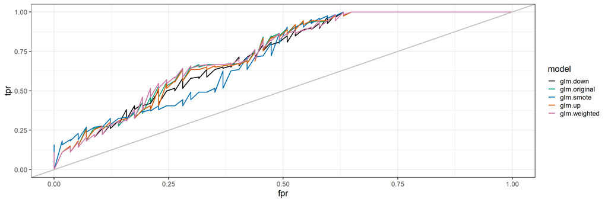

```r
custom_col <- c("#000000", "#009E73", "#0072B2", "#D55E00", "#CC79A7","#CC29E67")

ggplot(aes(x = fpr,  y = tpr, group = model), data = results_df_roc) +
  geom_line(aes(color = model), size = 1) +
  scale_color_manual(values = custom_col) +
  geom_abline(intercept = 0, slope = 1, color = "gray", size = 1) +
  theme_bw(base_size = 18)
```

# 9 Comparando os Resultados

Agora vamos comparar as previsões de todos esses modelos:

```r
comparison <- data.frame(model = names(model_list),
                         Sensitivity = rep(NA, length(model_list)),
                         Specificity = rep(NA, length(model_list)),
                         Precision = rep(NA, length(model_list)),
                         Recall = rep(NA, length(model_list)),
                         F1 = rep(NA, length(model_list)))
```

```r
for(name in names(model_list)){

  model <- get(paste0("cm_",name))

  comparison[comparison$model == name,'Sensitivity'] <- model[[4]]['Sensitivity']
  comparison[comparison$model == name,'Specificity'] <- model[[4]]["Specificity"]
  comparison[comparison$model == name,'Precision'] <- model[[4]]["Precision"]
  comparison[comparison$model == name,'Recall'] <- model[[4]]["Recall"]
  comparison[comparison$model == name,'F1'] <- model[[4]]["F1"]
}

comparison %>% arrange(desc(Sensitivity))
```

| model | Sensitivity | Specificity | Precision | Recall | F1 |
| --- | --- | --- | --- | --- | --- |
| glm.original | 1.0000000 | 0.3684211 | 0.7777778 | 1.0000000 | 0.8750000 |
| glm.weighted | 1.0000000 | 0.3684211 | 0.7777778 | 1.0000000 | 0.8750000 |
| glm.smote | 0.9285714 | 0.4385965 | 0.7852349 | 0.9285714 | 0.8509091 |
| glm.up | 0.8015873 | 0.5438596 | 0.7952756 | 0.8015873 | 0.7984190 |
| glm.down | 0.7777778 | 0.5438596 | 0.7903226 | 0.7777778 | 0.7840000 |

> Na tabela acima estão dispostos os resultados do modelos preditivos através de suas métricas. Vale observar o fato de que em todos os modelos os valores referêntes a métrica Sensitivity indicam que as previsões realizadas para a classe positiva Y da variável resposta Loan_Status possuem boa assertividade, ou seja, considerando as características socio-econõmicas do clientes conseguimos prever se o cliente é um bom pagador dado que ele é um bom pagador com boa assertividade.

Sérgio Carvalho

30 novembro, 2019